# Global Coffee Domestic Consumption Analysis

## Introduction

[figure not shown]

Coffee is a beverage brewed from roasted coffee beans. Darkly colored, bitter, and slightly acidic, coffee has a stimulating effect on humans, primarily due to its caffeine content. It has the highest sales in the world market for hot drinks. [Wikipedia](https://en.wikipedia.org/wiki/Coffee)

We have been provided with a dataset containing coffee consumption for in the last 30 years for 55 countries.

### Project Description

**Goal/Purpose:**

The goal is to analyze domestic coffee consumption in select countries over a 30 year period.

**Questions to be Answered:**

- What countries have the highest domestic coffee consumption?
- What countries have the lowest domestic coffee consumption?
- What continents have the highest domestic coffee consumption on average?
- What continents have the lowest domestic coffee consumption on average?
- What coffee type is most consumed globally?
- What coffee type is predominant in the top 10 countries with highest and lowest consumptions?
- What is the trend of global average consumption?
- What is the trend for each coffee type over the years?
- What is the trend in the top 10 countries with highest and lowest consumption?

### Data Description

**Content:**

This dataset is a CSV file of 55 data points which contains 33 columns.

**Description of Attributes:**

[output not shown]

**Acknowledgements:**

This dataset is provided by Brite Data.

## Data Loading

|  | Country | Coffee type | 1990/91 | 1991/92 | 1992/93 | 1993/94 | 1994/95 | 1995/96 | 1996/97 | 1997/98 | 1998/99 | 1999/00 | 2000/01 | 2001/02 | 2002/03 | 2003/04 | 2004/05 | 2005/06 | 2006/07 | 2007/08 | 2008/09 | 2009/10 | 2010/11 | 2011/12 | 2012/13 | 2013/14 | 2014/15 | 2015/16 | 2016/17 | … |
| --- | --- | --- | --- | --- | --- | --- | --- | --- | --- | --- | --- | --- | --- | --- | --- | --- | --- | --- | --- | --- | --- | --- | --- | --- | --- | --- | --- | --- | --- | --- |
| 0 | Angola | Robusta/Arabica | 1200000 | 1800000 | 2100000 | 1200000 | 1500000 | 600000 | 1200000 | 2400000 | 1800000 | 1200000 | 1200000 | 1200000 | 1200000 | 900000 | 900000 | 900000 | 1800000 | 1800000 | 1800000 | 1800000 | 1800000 | 1800000 | 1800000 | 1800000 | 1800000 | 1800000 | 1800000 | … |
| 1 | Bolivia (Plurinational State of) | Arabica | 1500000 | 1620000 | 1650000 | 1710000 | 1770000 | 1830000 | 1890000 | 1950000 | 1980000 | 2040000 | 2100000 | 2190000 | 2250000 | 2310000 | 2700000 | 2460000 | 2520000 | 2610000 | 2700000 | 2760000 | 2850000 | 2940000 | 3030000 | 3120000 | 3210000 | 3300000 | 3420000 | … |
| 2 | Brazil | Arabica/Robusta | 492000000 | 510000000 | 534000000 | 546000000 | 558000000 | 606000000 | 660000000 | 690000000 | 732000000 | 762000000 | 792000000 | 815400000 | 825000000 | 852000000 | 896760000 | 932280000 | 979860000 | 1026600000 | 1059600000 | 1103400000 | 1147920000 | 1183200000 | 1219800000 | 1205100000 | 1219980000 | 1230480000 | 1273500000 | … |
| 3 | Burundi | Arabica/Robusta | 120000 | 96000 | 102000 | 114600 | 120000 | 120000 | 120000 | 120000 | 120000 | 120000 | 120000 | 120000 | 120000 | 120000 | 120000 | 114360 | 93600 | 81420 | 86100 | 83940 | 120000 | 120000 | 120000 | 120000 | 120000 | 120000 | 120000 | … |
| 4 | Ecuador | Arabica/Robusta | 21000000 | 21000000 | 21000000 | 21000000 | 21000000 | 21000000 | 18000000 | 18000000 | 18000000 | 13800000 | 12000000 | 12000000 | 9000000 | 9000000 | 9000000 | 9000000 | 9000000 | 9000000 | 9000000 | 9000000 | 9000000 | 9000000 | 9000000 | 9300000 | 9300000 | 9300000 | 9300000 | … |

## Data cleaning

### Examine column names

### Check for redundant country information

|  | country | coffee_type | 1990/91 | 1991/92 | 1992/93 | 1993/94 | 1994/95 | 1995/96 | 1996/97 | 1997/98 | 1998/99 | 1999/00 | 2000/01 | 2001/02 | 2002/03 | 2003/04 | 2004/05 | 2005/06 | 2006/07 | 2007/08 | 2008/09 | 2009/10 | 2010/11 | 2011/12 | 2012/13 | 2013/14 | 2014/15 | 2015/16 | 2016/17 | … |
| --- | --- | --- | --- | --- | --- | --- | --- | --- | --- | --- | --- | --- | --- | --- | --- | --- | --- | --- | --- | --- | --- | --- | --- | --- | --- | --- | --- | --- | --- | --- |
| 28 | Equatorial Guinea | Robusta | 0 | 0 | 0 | 0 | 0 | 0 | 0 | 0 | 0 | 0 | 0 | 0 | 0 | 0 | 0 | 0 | 0 | 0 | 0 | 0 | 0 | 0 | 0 | 0 | 0 | 0 | 0 | … |
| 42 | Nepal | Arabica | 0 | 0 | 0 | 0 | 0 | 0 | 0 | 0 | 0 | 0 | 0 | 0 | 0 | 0 | 0 | 0 | 0 | 0 | 0 | 0 | 0 | 0 | 0 | 0 | 0 | 0 | 0 | … |

### OBSERVATION:

Two countries (Equatorial Guinea & Nepal) have zero values all through and will not be useful for the analysis

### TODO:

Drop countries with zero values all through.

### Examine coffee type values

```
Arabica            21
Robusta            14
Robusta/Arabica    10
Arabica/Robusta     8
Name: coffee_type, dtype: int64
```

### OBSERVATION:

`Robusta/Arabica` and `Arabica/Robusta` categories can be combined into one category

### TODO:

Replace `Arabica/Robusta` category with `Robusta/Arabica`

```
Arabica            21
Robusta/Arabica    18
Robusta            14
Name: coffee_type, dtype: int64
```

## Feature Engineering

### TODO:

- Create a continent column

|  | country | continent |
| --- | --- | --- |
| 0 | Angola | Africa |
| 1 | Bolivia | South America |
| 2 | Brazil | South America |
| 3 | Burundi | Africa |
| 4 | Ecuador | South America |
| 5 | Indonesia | Asia |
| 6 | Madagascar | Africa |
| 7 | Malawi | Africa |
| 8 | Papua New Guinea | Oceania |
| 9 | Paraguay | South America |
| 10 | Peru | South America |
| 11 | Rwanda | Africa |
| 12 | Timor-Leste | Unknown |
| 13 | Zimbabwe | Africa |
| 14 | Congo | Africa |

## Data Analysis

### Total domestic consumption analysis

#### Country & Continent

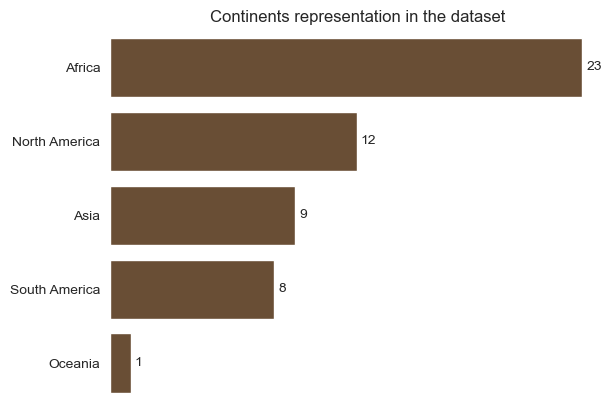

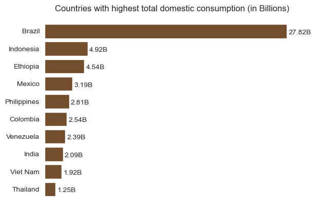

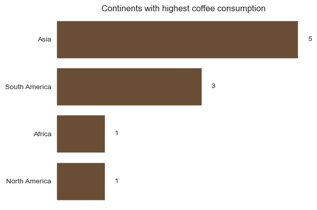

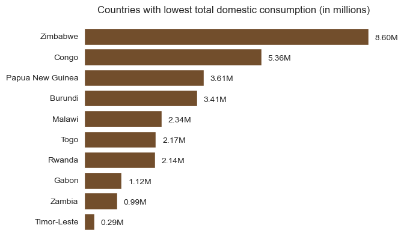

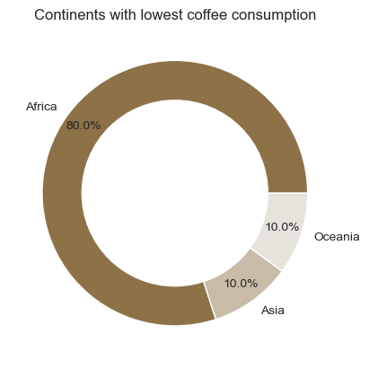

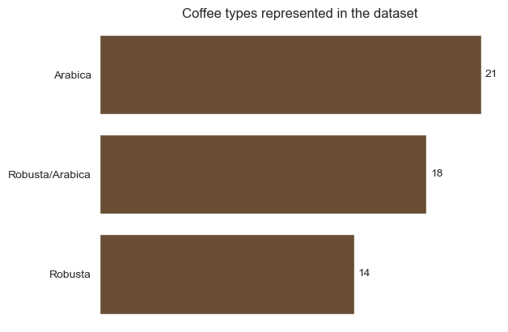

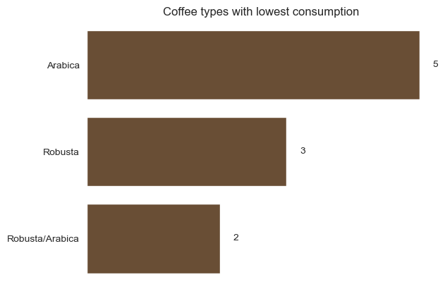

##### Observations

- In the 10 countries with lowest coffee consumption, *Arabica* is the predoninant coffee type with 50% of countries consuming *Arabica* exclusively.
- 20 % of the bottom 10 consume both coffees while 30% consume *Robusta* exclusively. the remaining consume *Arabica* exclusively
- None of the top 10 countries consume *Robusta* exclusively

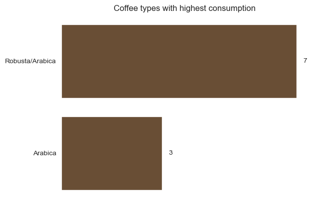

### Time series analysis

#### Global average consumption trends

|  | yearly_average |
| --- | --- |
| 1990/91 | 2.208590e+07 |
| 1991/92 | 2.289973e+07 |
| 1992/93 | 2.371862e+07 |
| 1993/94 | 2.388442e+07 |
| 1994/95 | 2.418132e+07 |

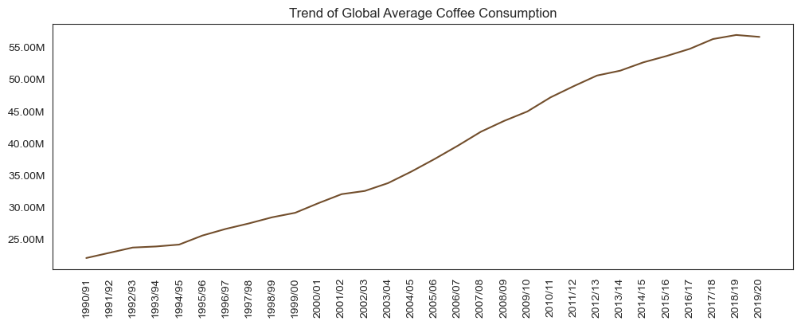

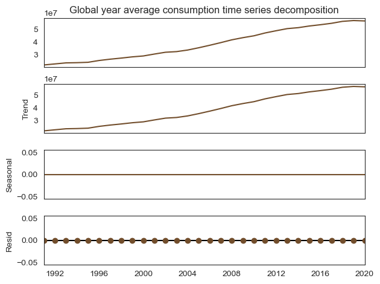

##### Observations

The decomposition of the global coffee consumption time series into its trend, seasonal, and residual components reveals the following:

**Trend:** There's a clear upward trend, indicating an increase in global coffee consumption over the years. This aligns with the earlier observation from the time series plot.

**Seasonality:** Given the decomposition was performed with a period of 1, seasonality is not applicable in this annual data. Seasonal decomposition typically requires data with more frequent observations (e.g., monthly or quarterly) to detect seasonal patterns.

**Residuals:** The residuals, which represent the noise or irregularities in the data after removing the trend and seasonality, do not show any systematic pattern, suggesting that the trend component captures most of the variability in the data.

This analysis confirms the long-term increase in global coffee consumption without any discernible seasonal patterns, likely due to the annual granularity of the data.

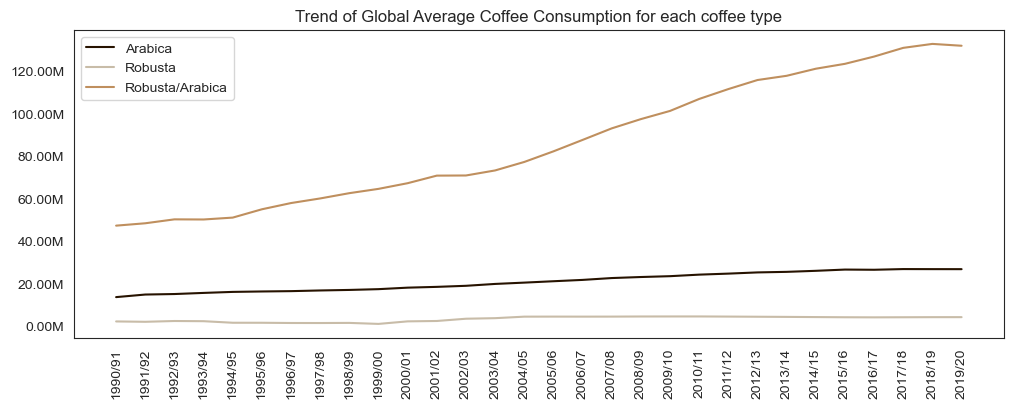

##### Observations

**Robusta/Arabica:** There's a clear upward trend for Robusta/Arabica consumption over the years. **Arabica:** Consumption of Arabica alone has increased albeit slightly over the years **Robusta:** The trend of consumption of Robusta alone is the lowest of all three. It fisplays a rather consistent pattern without noticeable increase.

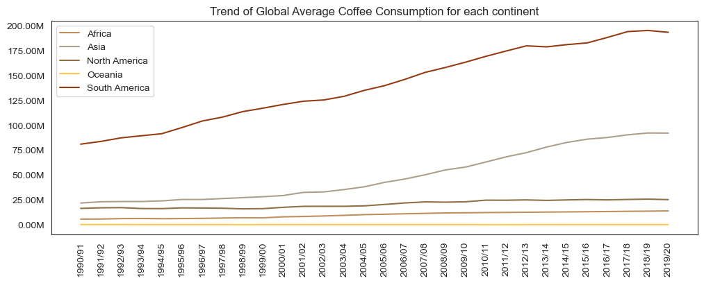

##### Observations

The trend of the global average coffee consumption for each continent reveals the following:

**South America:** The continent has the highest upward trend over the years

**Asia:** Asian countries also have a noticeable upward trend over the years.

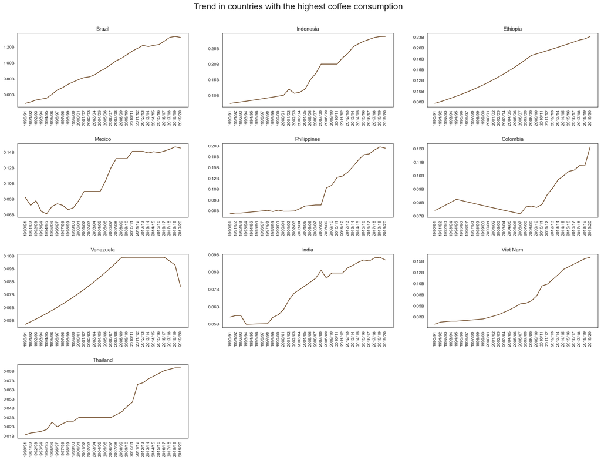

##### Observations

The trend of the global average coffee consumption for the top 10 consumer countries:

- There is a general upward trend in almost all the countries.
- *Venezuela* experienced an upward trend from 1990 to 2008, which remained steady until 2016, but has since shifted to a downward trajectory.
- *Columbia* initially experienced a downward trend from 1994 to 2007 but has increased noticeably ever since.

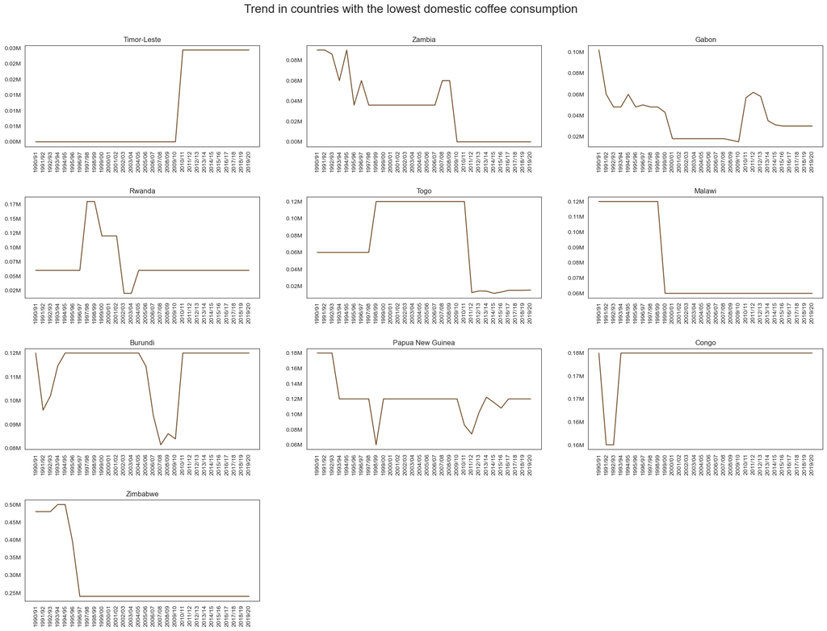

##### Observations

- Most of the countries in the bottom 10 consumption group have alternating trends.

## Conclusions

### Next Steps

- Data visualization and presentation using a data viz tool like Microsoft Power BI

## References & Resources

- [Arabica vs Robusta: Whats the difference?](https://bartalks.net/arabica-vs-robusta-whats-the-difference/)
- [Coffee consumption in Africa still low, opportunities for growth](https://www.howwemadeitinafrica.com/coffee-consumption-in-africa-still-low-opportunities-for-growth/52321/)
- [Venezuela coffee market](https://www.stellarmr.com/report/Venezuela-Coffee-Market/80)
- [Coffee brown color palette](https://www.color-hex.com/color-palette/59945)
- [Get continent name from country using pycountry](https://stackoverflow.com/questions/55910004/get-continent-name-from-country-using-pycountry)
- [Introduction to Time Series](https://dziganto.github.io/python/time%20series/Introduction-to-Time-Series/)
- [How to remove frame from a figure in Matplotlib](https://stackoverflow.com/questions/14908576/how-to-remove-frame-from-a-figure)